# HW3_MarkMalysa

2023-10-03

```r
USlifehistory <- read.csv('USlifehistory.csv')
galton_height <- read.csv('galton_height.csv')
galton_peas <- read.csv('galton_peas.csv')
```

```r
library(skimr)
library(ggplot2)
library(dplyr)
library(tidyr)
library(moderndive)
```

```r
yearsfrom1880 <- USlifehistory$year-1880
score_model1 <-lm(life_expectancy~yearsfrom1880, data= USlifehistory)
score_model1
```

```
##
## Call:
## lm(formula = life_expectancy ~ yearsfrom1880, data = USlifehistory)
##
## Coefficients:
##   (Intercept)  yearsfrom1880
##        44.893          0.281
```

```r
summary(score_model1)
```

```
##
## Call:
## lm(formula = life_expectancy ~ yearsfrom1880, data = USlifehistory)
##
## Residuals:
##     Min      1Q  Median      3Q     Max
## -7.9900 -1.7413  0.2189  1.5626  4.2937
##
## Coefficients:
##                Estimate Std. Error t value Pr(>|t|)
## (Intercept)   44.892556   0.403961  111.13   <2e-16 ***
## yearsfrom1880  0.281011   0.005007   56.13   <2e-16 ***
## ---
## Signif. codes:  0 '***' 0.001 '**' 0.01 '*' 0.05 '.' 0.1 ' ' 1
##
## Residual standard error: 2.368 on 137 degrees of freedom
## Multiple R-squared:  0.9583, Adjusted R-squared:  0.958
## F-statistic:  3150 on 1 and 137 DF,  p-value: < 2.2e-16
```

```r
get_regression_table(score_model1)
```

```
## # A tibble: 2 × 7
##   term          estimate std_error statistic p_value lower_ci upper_ci
##   <chr>            <dbl>     <dbl>     <dbl>   <dbl>    <dbl>    <dbl>
## 1 intercept       44.9       0.404     111.        0   44.1     45.7
## 2 yearsfrom1880    0.281     0.005      56.1       0    0.271    0.291
```

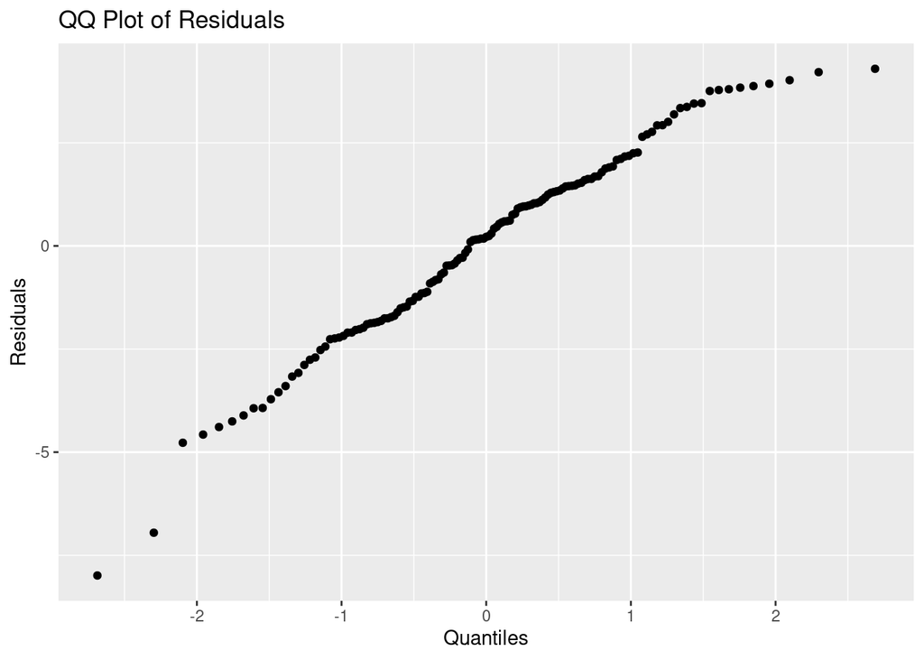

```r
residuals <- score_model1$residuals
qq <- ggplot(data = USlifehistory, mapping = aes(sample = residuals)) +
  stat_qq() +
  labs(title = "QQ Plot of Residuals",
       x = "Quantiles",
       y = "Residuals")
qq
```

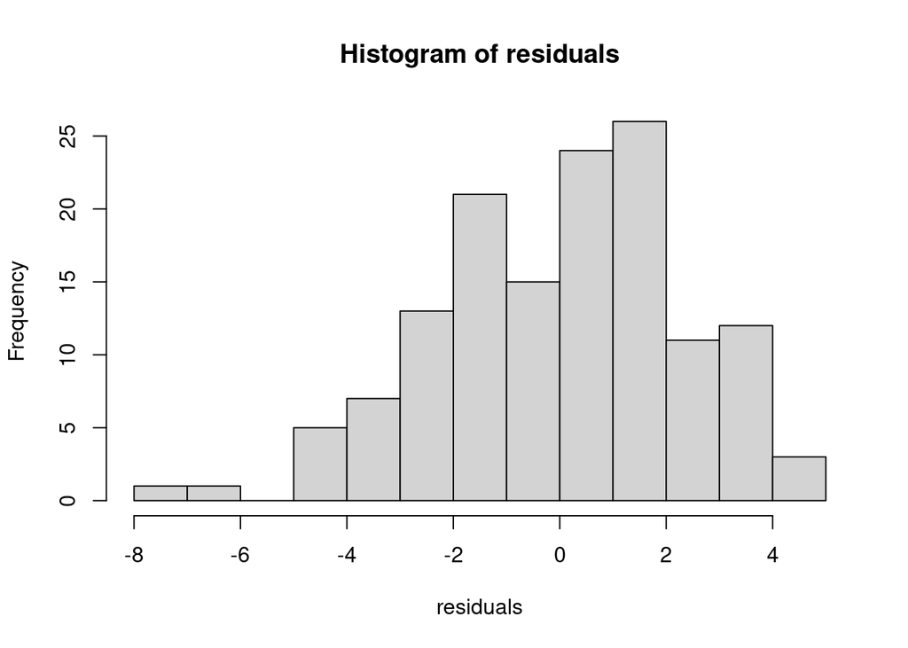

```r
hist(residuals)
```

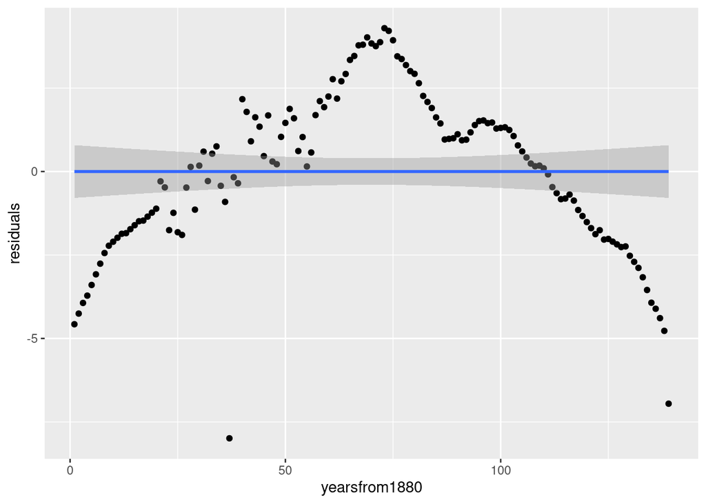

```r
ggplot(data=USlifehistory, aes(x=yearsfrom1880, y=residuals)) + geom_point() + geom_smooth(method = lm)
```

```r
galton_height$mid_Parent_height <- (galton_height$Father + galton_height$Mother)/2

meanratio <- mean(galton_height$Height[galton_height$Gender == "M"]) / mean(galton_height$Height[galton_height$Gender == "F"])


galton_height <- galton_height %>%
  mutate(
    adj_height_Mother = Mother*meanratio
  )

galton_height <- galton_height %>%
  mutate(
    adj_height = ifelse(Gender == "F", (Height*meanratio), Height)
  )
galton_height$mid_Parent_height <- (galton_height$Father + galton_height$adj_height_Mother)/2
```

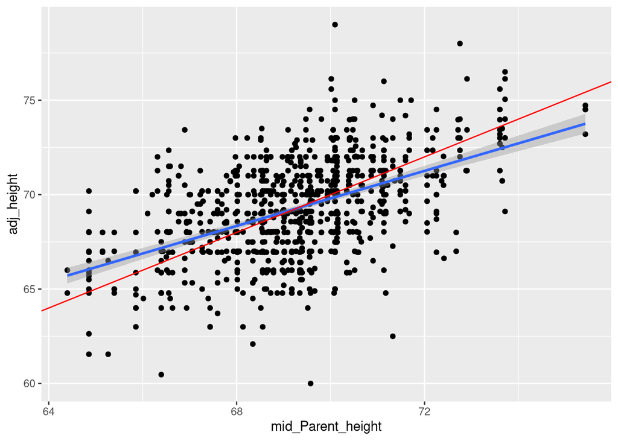

```r
ggplot(data=galton_height, aes(x=mid_Parent_height, y=adj_height)) + geom_point() + geom_smooth(method = lm) + geom_abline(intercept = 0, slope = 1, color = "red")
```

```r
mean(galton_height$adj_height)
```

```
## [1] 69.22882
```

```r
mean(galton_height$mid_Parent_height)
```

```
## [1] 69.21693
```

```r
mean(galton_height$adj_height[galton_height$mid_Parent_height < 73 & galton_height$mid_Parent_height > 72])
```

```
## [1] 71.31255
```

```r
regressModel1 <- lm(data = galton_height, adj_height~mid_Parent_height)
summary(regressModel1)
```

```
##
## Call:
## lm(formula = adj_height ~ mid_Parent_height, data = galton_height)
##
## Residuals:
##     Min      1Q  Median      3Q     Max
## -9.4898 -1.4752  0.1045  1.5194  9.1312
##
## Coefficients:
##                   Estimate Std. Error t value Pr(>|t|)
## (Intercept)       18.77359    2.84058   6.609 6.63e-11 ***
## mid_Parent_height  0.72894    0.04102  17.768  < 2e-16 ***
## ---
## Signif. codes:  0 '***' 0.001 '**' 0.01 '*' 0.05 '.' 0.1 ' ' 1
##
## Residual standard error: 2.233 on 896 degrees of freedom
## Multiple R-squared:  0.2606, Adjusted R-squared:  0.2597
## F-statistic: 315.7 on 1 and 896 DF,  p-value: < 2.2e-16
```

```r
plot(regressModel1)
```

[figure not shown]

As seen in the regression model the p-value is less than 0.05, which means this model is significant.

#2-5 If the parents’ mid-height increases by 1 inch .. As seen from the summary of the regression model an inch increase in the parents mid height will result in an expected 0.72894 inch increase in the childs adjusted height. This expected increase is less than 1 inch.

```r
regressModel1 <- lm(data = galton_height, adj_height~mid_Parent_height)
newValues <- data.frame(mid_Parent_height = c(64, 68, 70, 72, 76))
new_estimates <- predict(regressModel1, newValues)
new_estimates
```

```
##        1        2        3        4        5
## 65.42597 68.34174 69.79963 71.25752 74.17329
```

```r
new_estimates - mean(galton_height$adj_height)
```

```
##          1          2          3          4          5
## -3.8028467 -0.8870731  0.5708137  2.0287005  4.9444741
```

```r
(new_estimates - mean(galton_height$adj_height))/sd(galton_height$adj_height)
```

```
##          1          2          3          4          5
## -1.4650736 -0.3417512  0.2199100  0.7815712  1.9048936
```

In the above result of the code, 1 is paired with 64, 2 is paired with 68, 3 is paired with 70, 4 is paired with 72, and 5 is paired with 76. The row underneath that represents the difference between the predicted value and the mean. The last row represents how many standard deviations the predicted values are from the mean value.

```r
regressModel2 <- lm(data = galton_height, mid_Parent_height~adj_height)
```

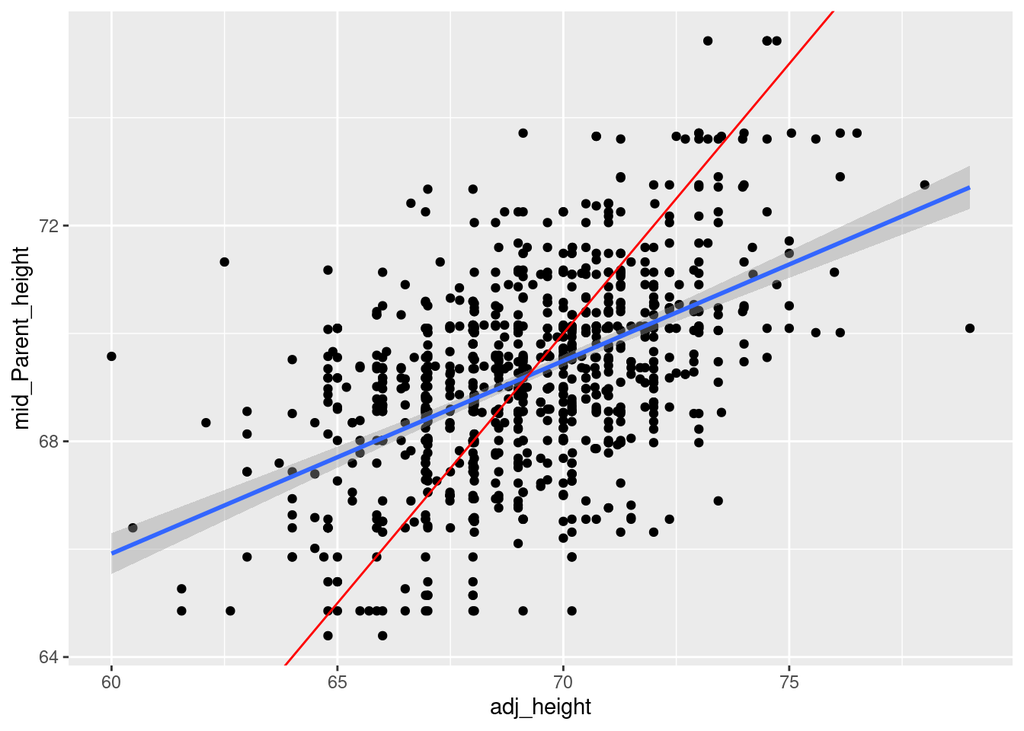

```r
ggplot(data=galton_height, aes(x=adj_height, y=mid_Parent_height)) + geom_point() + geom_smooth(method = lm) + geom_abline(intercept = 0, slope = 1, color = "red")
```

```r
mean(galton_height$mid_Parent_height[galton_height$adj_height < 73 & galton_height$adj_height > 72])
```

```
## [1] 70.47901
```

```r
regressModel2 <- lm(data = galton_height, mid_Parent_height~adj_height)
summary(regressModel2)
```

```
##
## Call:
## lm(formula = mid_Parent_height ~ adj_height, data = galton_height)
##
## Residuals:
##     Min      1Q  Median      3Q     Max
## -4.7051 -1.0531  0.0564  1.0167  4.7883
##
## Coefficients:
##             Estimate Std. Error t value Pr(>|t|)
## (Intercept) 44.47182    1.39362   31.91   <2e-16 ***
## adj_height   0.35744    0.02012   17.77   <2e-16 ***
## ---
## Signif. codes:  0 '***' 0.001 '**' 0.01 '*' 0.05 '.' 0.1 ' ' 1
##
## Residual standard error: 1.564 on 896 degrees of freedom
## Multiple R-squared:  0.2606, Adjusted R-squared:  0.2597
## F-statistic: 315.7 on 1 and 896 DF,  p-value: < 2.2e-16
```

```r
plot(regressModel2)
```

[figure not shown]

As seen in the above summary the p-value is less than 0.05 making the model significant.

#3-4 If the child’s height increases by 1 inch.. If the child’s height increases by 1 inch the parents mid height will increase by 0.35744 inches which is smaller than 1 inch.

```r
newValues2 <- data.frame(adj_height = c(64, 68, 70, 72, 76))
new_estimates2 <- predict(regressModel2, newValues2)
new_estimates2
```

```
##        1        2        3        4        5
## 67.34794 68.77770 69.49258 70.20746 71.63722
```

```r
new_estimates2 - mean(galton_height$mid_Parent_height)
```

```
##          1          2          3          4          5
## -1.8689854 -0.4392277  0.2756511  0.9905300  2.4202877
```

```r
(new_estimates2 - mean(galton_height$mid_Parent_height))/sd(galton_height$mid_Parent_height)
```

```
##          1          2          3          4          5
## -1.0282583 -0.2416496  0.1516548  0.5449591  1.3315678
```

In the above result of the code, 1 is paired with 64, 2 is paired with 68, 3 is paired with 70, 4 is paired with 72, and 5 is paired with 76. The row underneath that represents the difference between the predicted value and the mean. The last row represents how many standard deviations the predicted values are from the mean value.

# Use the above results to explain regression to the mean.

So the above results essentially prove the swap between extreme cases as show by the two regression models. If a child’s adjusted average height is more of an extreme case, the mid height of the parents is more likly to be closer to the mean. This is the same for the mid height of the parents, since if it is more extreme than the child’s adjusted average height is more likly to be average. This can be seen in results of the two models and the visaulisations of the 2 models.